# Project 3: Stroop Effect Analysis

## Author: Félix Carlos Camacho Criado

- Summary
- Background information
- Question 1
- Question 2
- Question 3
- Question 4
- Question 5

#### Summary:

In this report I will perfom and answer some statistical questions based on the analysis of the Stroop effect test.

#### Background Information

In a Stroop task, participants are presented with a list of words, with each word displayed in a color of ink. The participant’s task is to say out loud the color of the ink in which the word is printed. The task has two conditions: a congruent words condition, and an incongruent words condition. In the congruent words condition, the words being displayed are color words whose names match the colors in which they are printed: for example RED, BLUE. In the incongruent words condition, the words displayed are color words whose names do not match the colors in which they are printed: for example PURPLE, ORANGE. In each case, we measure the time it takes to name the ink colors in equally-sized lists. Each participant will go through and record a time from each condition.

#### Q1: What is our independent variable? What is our dependent variable?

The independent variable is the the type/condition of word which is displayed on participant screen. Based on the nature of the test, the words type can be congruent or incongruent words depending on the name match or not with the color.

The dependent variable is the time that each participant spend on saying out the color of the ink in which the word is printed.

#### Q2: 2. What is an appropriate set of hypotheses for this task? What kind of statistical test do you expect to perform? Justify your choices.

Based on the background, the available information is the recorded time which spent each participant to play the test using both two conditions. So, an appropiate set of hypothesis would take into consideration the recorded times for each sample in order to make some assumptions.

The Stroop effect is a demonstration of interference in the reaction time of a task. Therefore if I want to validate this, I would consider a null hypothesis $(Ho)$ based on the idea that the time recorded for test which used congruent words last the same than the time for test which included incongruent words. If this is not happening it would means there is a significant difference between the time recorded for completing both test, represented as the Alternative Hypothesis $(Ha)$.

In the mathematical statement would be like this:

$$ Ho = \mu C - \mu I = 0 \\ Ha = \mu C - \mu I \neq 0 $$

At $\alpha $ level = 0.05

Where:

$\mu C $ = Average time for completing the test using congruent words.

$\mu I $ = Average time for completing the test using incongruent words.

In this case we have a first sample of participants who played the Stroop test using congruent words and another sample of participants who played it using the incongruent words. Both samples are dependent because the same subject takes the test twice. In addition, I don't have information about parameters from the population like the mean or standard deviation I only have information about the samples so I will perfom a statistical test in order to infer the result and came a conclusion about the population.

Consequently, I will perform a two tailed dependent sample t-test because I want to determine whether the mean difference between these two samples is zero.

#### Q3: Report some descriptive statistics regarding this dataset. Include at least one measure of central tendency and at least one measure of variability.

```python
#import libraries
import pandas as pd
import matplotlib.pyplot as plt
import seaborn as sns
import warnings
warnings.filterwarnings("ignore")

#import magic lines
%pylab inline
```

```python
#reading data set
stroop = pd.read_csv('stroopdata.csv')

#showing first lines of the dataset
stroop.head()
```

|  | Congruent | Incongruent |
| --- | --- | --- |
| 0 | 12.079 | 19.278 |
| 1 | 16.791 | 18.741 |
| 2 | 9.564 | 21.214 |
| 3 | 8.630 | 15.687 |
| 4 | 14.669 | 22.803 |

```python
len(stroop) #size of the sample.
```

```
24
```

```python
#Reporting descriptive statistics including measures of central tendency and variability.
stroop.describe()
```

|  | Congruent | Incongruent |
| --- | --- | --- |
| count | 24.000000 | 24.000000 |
| mean | 14.051125 | 22.015917 |
| std | 3.559358 | 4.797057 |
| min | 8.630000 | 15.687000 |
| 25% | 11.895250 | 18.716750 |
| 50% | 14.356500 | 21.017500 |
| 75% | 16.200750 | 24.051500 |
| max | 22.328000 | 35.255000 |

#### Q4: Provide one or two visualizations that show the distribution of the sample data. Write one or two sentences noting what you observe about the plot or plots.

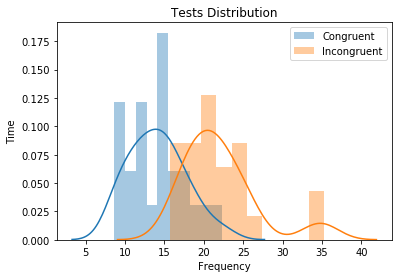

```python
# plot distributions
plt.figure()
sns.distplot(stroop["Congruent"], bins=10 )
sns.distplot(stroop["Incongruent"], bins=10 )

plt.xlabel("Frequency")
plt.ylabel("Time")
plt.legend(('Congruent','Incongruent'))
plt.title('Tests Distribution')
plt.show()
```

I observe there is higher dispersion in the incongruent values than in the congruent values.

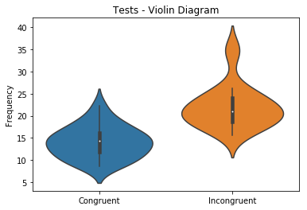

```python
# plot Violin graph
plt.figure()

sns.violinplot(data=stroop.iloc[:,0:2])
plt.ylabel("Frequency")
plt.title('Tests - Violin Diagram')
plt.show()
```

Most of values for congruent serie falls within a range between 10 and 20, but for the incongruent serie most values falls in a higher range between 15 and 25 including some outliers greater than 30.

#### Q5: Now, perform the statistical test and report your results. What is your confidence level and your critical statistic value? Do you reject the null hypothesis or fail to reject it? Come to a conclusion in terms of the experiment task. Did the results match up with your expectations?

**Size =** 24  
**Degrees of freedom =** 23  
**Confidence level =** 95%  
**$\alpha $ level =** 0.05  
**t-critical values for a two tailed test (0.025 tail probability p) =** $ \pm$2.069

```python
size = len(stroop['Congruent']) #obtaining size.
```

```python
mean_dif = stroop['Incongruent'].mean() - stroop['Congruent'].mean() #Calculating the differences between the means from each samples
mean_dif
```

```
7.964791666666665
```

```python
sample_dif = (stroop['Incongruent'] - stroop['Congruent'])
```

```python
sample_dif_2 = (sample_dif - mean_dif).pow(2).sum()
```

```python
std_samples = sqrt(sample_dif_2 /(size-1)) #Calculating Standard Deviation from the differences between the samples
```

```python
sd_error = std_samples/sqrt(size) #Calculating Standard Error
```

```python
sd_error
```

```
0.9930286347783406
```

$$ T-Statistic = \frac{Difmean_i - Difmean_c}{Standard Error} $$

```python
tstatistic = (mean_dif/sd_error) #Calculating T-Statistic.
```

```python
tstatistic.round(2)
```

```
8.02
```

Our t-statistic value (8.02) is quite far from our t-critical value (2.069), so I reject the null hypothesis, in other words, I accept the alternative hypothesis.

The two-tailed P value is less than 0.0001 for a t-statistic of 8.02 and 23 degrees of freedom. By conventional criteria, this difference is considered to be extremely statistically significant because our p-value quite is lower than our alpha level (0.0001 < 0.05).

In conclusion, after this results we can say that taking into consideration these samples, there is a signficant difference in the time that the participants spend for completing the Stroop test using incongruent words in comparison with the time they spend using congruent words. Personally this is not a surprise as before completing this project and I tried the Stroop test and I spent 10 seconds more to complete it using incongruent words.